# Лабораторная работа №2

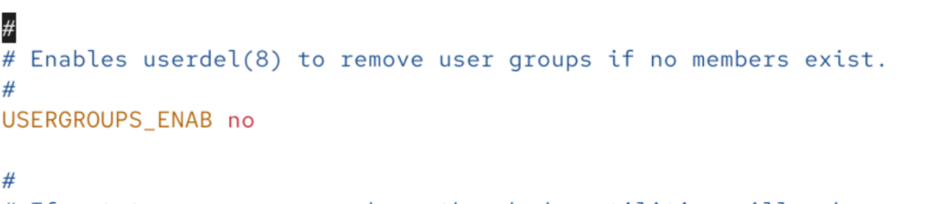

Рисунок 30: USERGROUPS_ENAB

Переходим в каталог /etc/skel и создаем каталоги Pictures и Documents (рис.31)

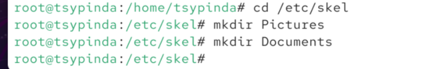

Рисунок 31: Переход в каталог /etc/skel, создание каталогов Pictures и Documents

Открываем для редактирования файл .bashrc (рис.32), добавляем строку export EDITOR=/usr/bin/vim (рис.33)

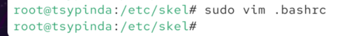

Рисунок 32: sudo vim .bashrc

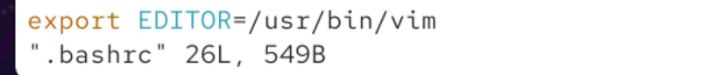

Рисунок 33: export EDITOR=/usr/bin/vim

Переключаемся на учетную запись alice, создаем пользователя carol. Устанавливаем пароль (рис.34)

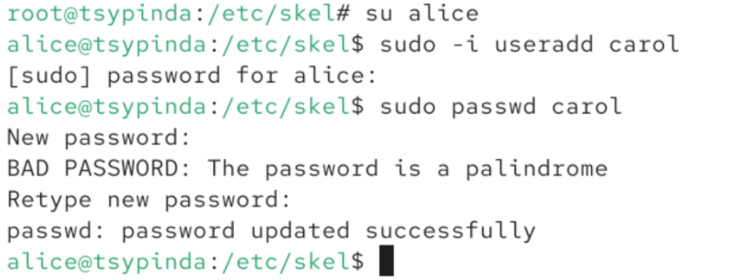

Рисунок 34: Создание carol

Переключаемся на carol. Проверяем первоначальную группу (100(users)), убеждаемся в наличии каталогов documetns и Pictures (рис.35)

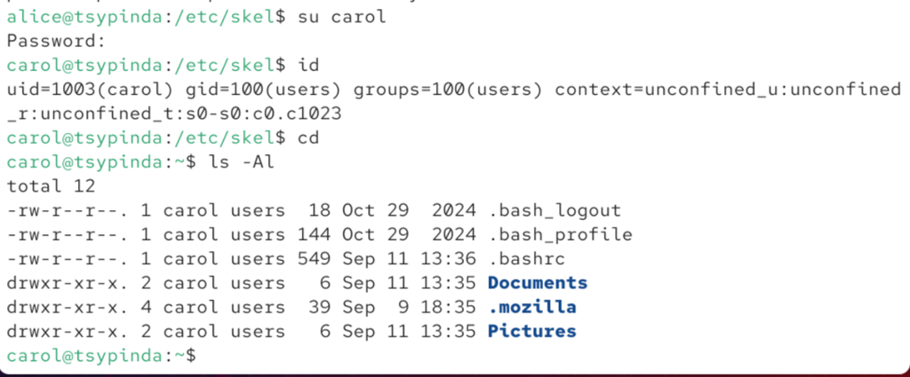

Рисунок 35: Проверка carol

Переключаемся на alice и вызываем строку записи о пароле carol (рис.36). В этой строке разделение показывается с помощью :. Каждая часть означает следующее: 1. Имя пользователя  
2. Пароль в зашифрованном виде  
3. Количество дней с 1 января 1970 года до момента создания пользователя  
4. Количество дней, после которых можно будет сменить пароль  
5. Количество дней, через которые пароль станет недействительным  
6. Количество дней, за сколько система предупредит пользователя о том, что его пароль вскоре станет недействительным  
7. Количество дней, по прошествии которых пользователь станет недейсвтительным 8. Сколько дней прошло после того, как пользователь стал недействительным  
9. Дополнительная секция

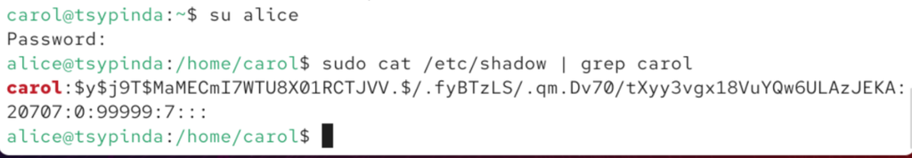

Рисунок 36: sudo cat /etc/shadow | grep carol

Изменяем свойства пароля carol (рис.37)

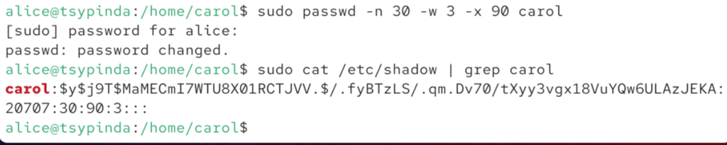

Рисунок 37: sudo passwd -n 30 -w 3 -x 90 carol

Убеждаемся, что идентификатор alice существует во всех трех файлах (рис.38)

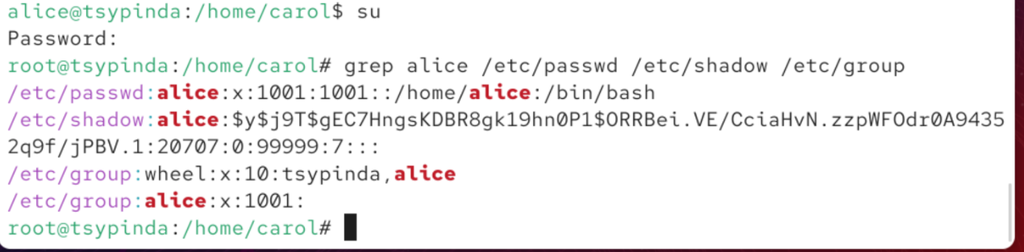

Рисунок 38: grep alice /etc/passwd /etc/shadow /etc/group

Убеждаемся, что идентификатор carol существует не во всех трех файлах (рис. 39)

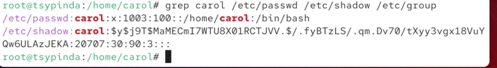

Рисунок 39: sudo grep carol /etc/passwd /etc/shadow /etc/group

## Работа с группами

Переходим в alice и создаем группы main third (рис.40)

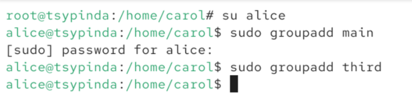

Рисунок 40: sudo groupadd main, sudo groupadd third

Создаем пользователей dave, dan и david, а также задаем им пароли (рис. 41)

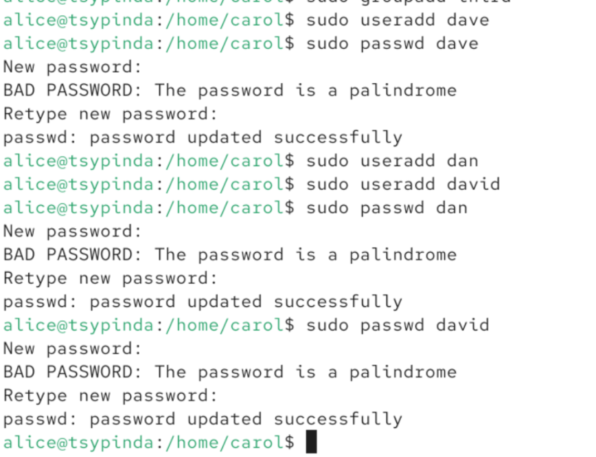

Рисунок 41: sudo useradd dave, dan, david; sudo passwd dan, dave, david

Добавляем пользователей в группы (рис.42)

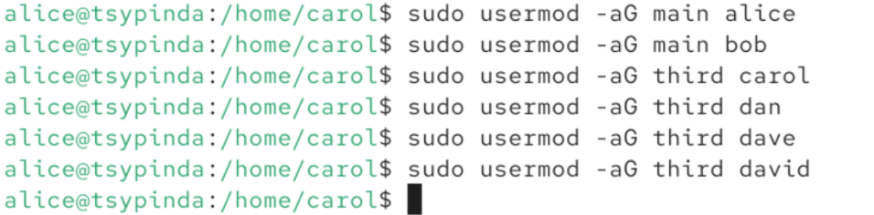

Рисунок 42: sudo usermod -aG группа пользователь

Убеждаемся, что carol правильно добавлен в группу third (рис.43)

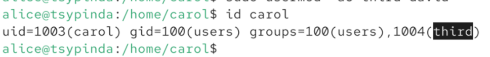

Рисунок 43: id carol

Определяем, участниками каких групп являются другие созданные пользователи (рис.44)

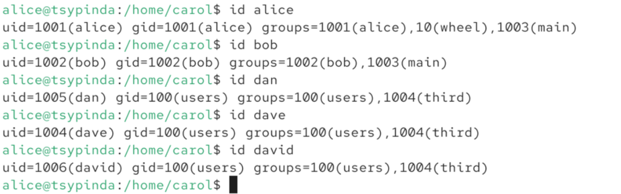

Рисунок 44: Другие пользователи

# Выводы

Я получил представление о работе с учётными записями пользователей и группами пользователей в операционной системе типа Linux.